# HTML report

Mendoza Insurance company has recently come under increased pressure to improve its operation as the investment side of its business has not been performing well. One of their greatest concerns has been fraudulent claims.

Even worse, the company’s business analytics specialist was recently poached by one of its competitors who offered her quite a lucrative salary/benefits package. She relocated and started with them three months ago. The company realizes it cannot hire such a valuable expert quickly, and has contacted you to get advice on some key decisions.

You have been given access to a random sample of 4,415 of their claims data in 2008. This can be found in the file: `insurance.rda`. Mendoza Insurance is eagerly awaiting your recommendations.

For the following, please use **1% significance level**, i.e., $\alpha=1\%$. To get the full credits, you should show either your code or your analysis.

### 1. Should Mendoza Insurance raise premiums this year? (5 points)

Under Mendoza Insurance policy guidelines, a policy premium increase is merited if the average claim amount has increased by at least 5% over the previous year. The accounting department has reported that the average claim amount in 2007 was $63,500.

Note: The `claim_amount` variable in the dataset is reported in $1,000’s of dollars.

1. Make sure to clearly describe your null and alternative hypotheses. (Hint: Think about when the firm would take an action to increase a policy premium.)
   - H0: mu >= 66.675
   - Ha: mu < 66.675
2. Conduct hypothesis testing and report the result.

```r
result <- single_mean(
  insurance,
  var = "claim_amount",
  comp_value = 66.675,
  alternative = "less"
)
summary(result)
```

```
Single mean test
Data      : insurance
Variable  : claim_amount
Confidence: 0.95
Null hyp. : the mean of claim_amount = 66.675
Alt. hyp. : the mean of claim_amount is < 66.675

   mean     n n_missing      sd    se    me
 73.011 4,415         0 144.401 2.173 4.261

  diff    se t.value p.value   df   0%    95%
 6.336 2.173   2.915   0.998 4414 -Inf 76.586

Signif. codes:  0 '***' 0.001 '**' 0.01 '*' 0.05 '.' 0.1 ' ' 1
```

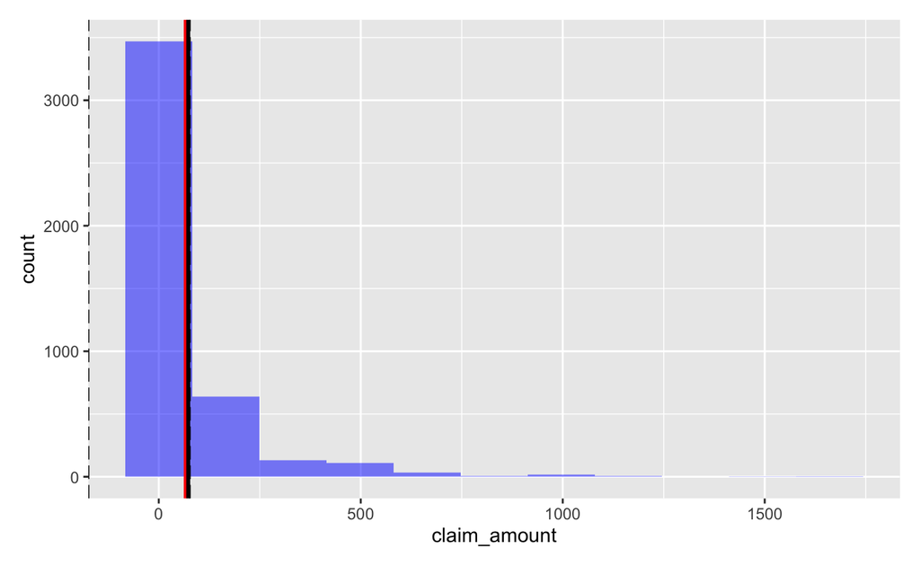

```r
plot(result, plots = "hist", custom = FALSE)
```

Since p-value is 0.998 and way bigger than 1% significant level, we do not reject the null hypothesis and claims that Mendoza Insurance should increase its premium.

3. Would you order a reevaluation of the policy premiums for a premium increase based on your result? Why or why not?

### 2. Should Mendoza Insurance charge different demographic groups different premiums? (5 points)

The company would like to revisit how their current premiums take into account **workforce** status. As of now, a customer’s **workforce** does not affect the premium. If different demographic groups exhibit different claims behavior, perhaps they should be charged different premiums. For instance, if the retired tend to file smaller claims than the non-retired, maybe the retired should be provided some discounts. Mendoza Insurance would like you to examine the claims data to assess the following questions: **Do retirees claim lower amounts on their policy?** (Hint: Make use of the `retire` variable in the dataset. Also, consider what would happen if the retirees’ claim amounts are lower.)

1. Clearly describe your null and alternative hypotheses.
   - H0: mu_retire >= mu_non_retire
   - Ha: mu_retire < mu_non_retire
2. Conduct hypothesis testing and report the result.

```r
result <- compare_means(
  insurance,
  var1 = "retire",
  var2 = "claim_amount",
  alternative = "less"
)
summary(result, show = FALSE)
```

```
Pairwise mean comparisons (t-test)
Data      : insurance
Variables : retire, claim_amount
Samples   : independent
Confidence: 0.95
Adjustment: None

 retire   mean     n n_missing      sd    se    me
    Yes 37.313   574         0  60.529 2.526 4.962
     No 78.346 3,841         0 152.325 2.458 4.819

 Null hyp.  Alt. hyp.  diff    p.value
 Yes = No   Yes < No   -41.032 < .001  ***

Signif. codes:  0 '***' 0.001 '**' 0.01 '*' 0.05 '.' 0.1 ' ' 1
```

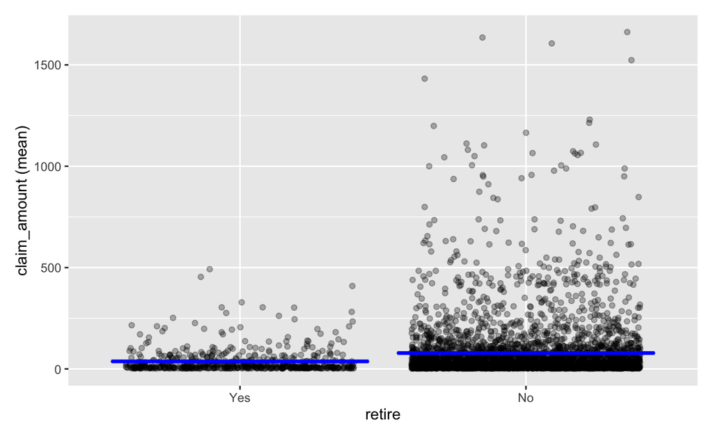

```r
plot(result, plots = "scatter", custom = FALSE)
```

Since p-value is smaller than the significant value, we reject the null hypothesis and claims that retired tend to file smaller claims than the non-retired.

3. Provide your recommendation based on your analysis.

From the analysis, the retired should be charged different premiums.

### 3. Have Mendoza Insurance’s efforts to catch fraud been effective? (5 points)

After analyzing the claim data from 2007, they ultimately determined that 9.8% of all claims in 2007 were fraudulent. However, the management team was concerned as the current manual fraudulent detection process might not be so efficient. To improve the fraudulent claim detection, the management team recommended to implement fraud detection algorithms in Mendoza’s claims processes. The recommendation was accepted and Mendoza Insurance invested heavily in implementing the new fraud detection algorithms at the end of 2007.

1. The management team wants to know if their recommendation, i.e., investment in fraud detection algorithms, was effective in 2008. (Hint: Make use of the `fraudulent` variable.) Clearly describe your null and alternative hypotheses. For simplicity, you may assume that policy holders are no more, or less, likely to file fraudulent claims in 2008 compared to 2007. Also, you may assume that any difference in detection rate can be linked to the new detection algorithms.
   - H0: p <= 0.098
   - Ha: p > 0.098
2. Conduct hypothesis testing and report the result.

```r
result <- single_prop(
  insurance,
  var = "fraudulent",
  lev = "Yes",
  comp_value = 0.098,
  alternative = "greater"
)
summary(result)
```

```
Single proportion test (binomial exact)
Data      : insurance
Variable  : fraudulent
Level     : Yes in fraudulent
Confidence: 0.95
Null hyp. : the proportion of Yes in fraudulent = 0.098
Alt. hyp. : the proportion of Yes in fraudulent > 0.098

     p  ns     n n_missing    sd    se    me
 0.105 463 4,415         0 0.306 0.005 0.009

  diff  ns p.value    5%  100%
 0.007 463   0.067 0.097 1.000 .

Signif. codes:  0 '***' 0.001 '**' 0.01 '*' 0.05 '.' 0.1 ' ' 1
```

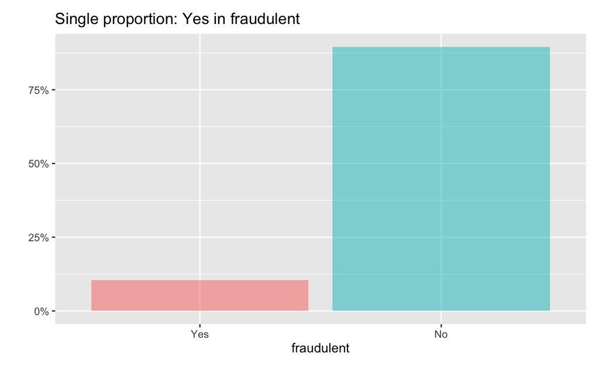

```r
plot(result, plots = "bar", custom = FALSE)
```

3. Do you believe their investments have enabled them to identify fraud significantly better? Please explain your reasoning.

### 4. Are fraudulent claim amounts higher or lower than non-fraudulent claim amounts? (5 points)

In other words, are fraudulent claim amounts equal to non-fraudulent claim amounts?

1. Clearly describe your null and alternative hypotheses.
   - H0: mu_f = mu_Nf
   - Ha: muf != mu_Nf
2. Conduct hypothesis testing and report the result.

```r
result <- compare_means(
  insurance,
  var1 = "fraudulent",
  var2 = "claim_amount"
)
summary(result, show = FALSE)
```

```
Pairwise mean comparisons (t-test)
Data      : insurance
Variables : fraudulent, claim_amount
Samples   : independent
Confidence: 0.95
Adjustment: None

 fraudulent   mean     n n_missing      sd    se     me
        Yes 66.009   463         0 133.863 6.221 12.225
         No 73.831 3,952         0 145.580 2.316  4.540

 Null hyp.  Alt. hyp.             diff   p.value
 Yes = No   Yes not equal to No   -7.822 0.239

Signif. codes:  0 '***' 0.001 '**' 0.01 '*' 0.05 '.' 0.1 ' ' 1
```

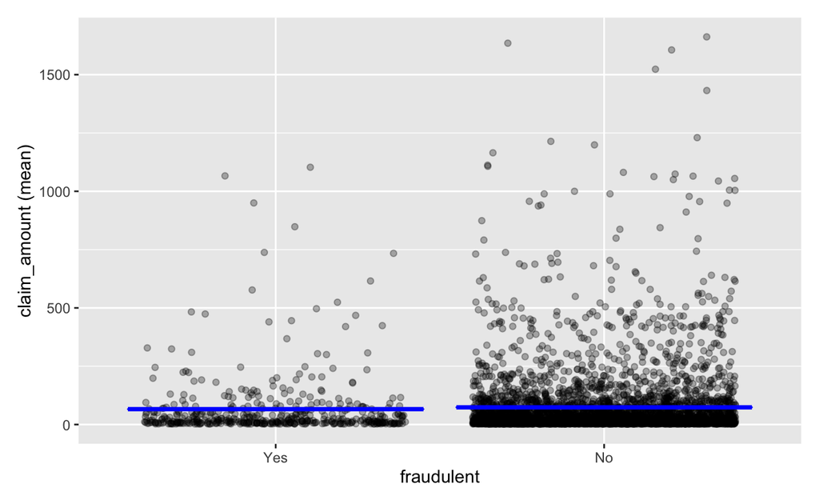

```r
plot(result, plots = "scatter", custom = FALSE)
```

3. Provide your advice based on your analysis.